# Visualization Project

Wentao Wu

2022-09-27

# Drivers Involved In Fatal Collisions Who Were Not Distracted

[figure not shown]

# Drivers Involved In Fatal Collisions Who Had Not Been Involved In Any Previous Accidents

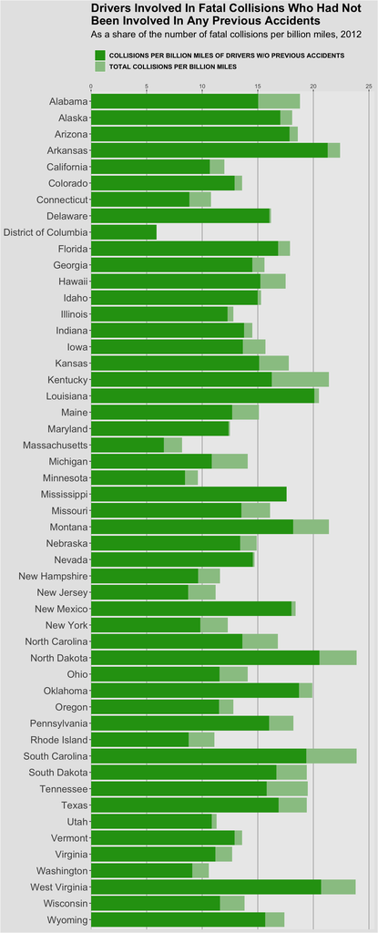

# Drivers Involved In Fatal Collisions While Speeding

[figure not shown]

# Drivers Involved In Fatal Collisions While Alcohol-Impaired

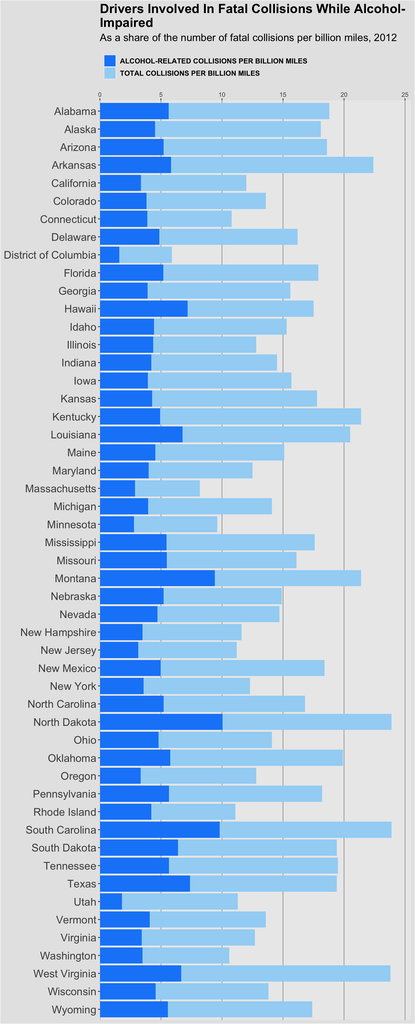

# Average Combined Insurance Premium

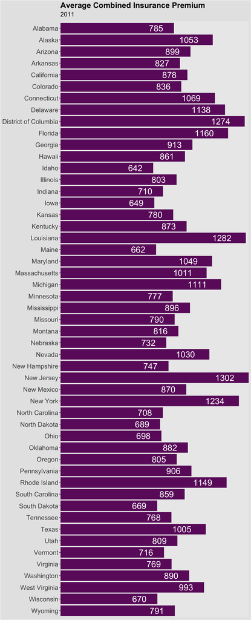

# Losses Incurred By Insurance Companies

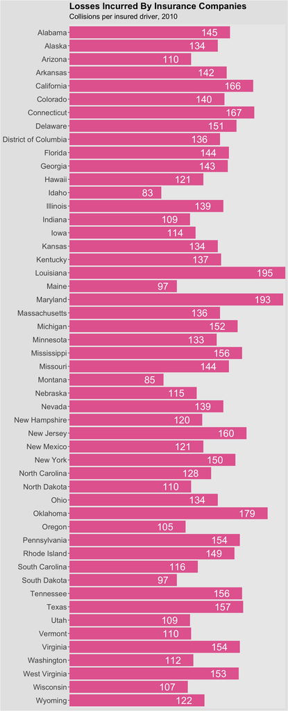

## Technical Discussion

In this part, I will start a discussion on which steps and functions I mainly use specifically, and how they work to create my visualization plots. At the beginning, I set the display size of the images, access the library to be used, read the data and classify them, which are quite easy. In the graphic recreation part, the most important functions are ggplot(), coord_flip() and theme(). ggplot() and coord_flip() mainly provides a mapping of data to pictures and flips them, which are the foundation of all. theme() Literally sets the theme of the image, such as background, axis, legend, title font, etc. It is because of theme() that the picture is restored as much as possible. Other functions are more auxiliary such as providing titles and setting width, and I use additionally geom_text() to display the values on the picture for the last two pictures. It is not difficult to display data in visualization project, where the recreation of details matters. In the display of histograms, because I didn’t fully understand the context of each data type, I used fct_rev() incorrectly, resulting in strange output, which bothered me for hours. For the color election, I used this external webiste: https://htmlcolorcodes.com/

## Reference

Article Title: Dear Mona, Which State Has The Worst Drivers? Hyperlink: https://fivethirtyeight.com/features/which-state-has-the-worst-drivers/